# Digitizing protocol

Jeffrey A. Walker

11/5/2020

**Setup**

1. Open the project spreadsheet. It is a google sheet in the folder with the video files
2. Copy the name of the file you are going to open and paste into the project spreadsheet in the “file” field
3. In Fiji, open the video file using Import > AVI, choose OK (do not open by double clicking the video file itself)
4. Expand the size of the window containing the video to fill most of your screen and zoom in so the video fills the window size

**Set the scale**

5. Click on the line tool
6. Shift-click on two *distant* points along a grid-line in horizontal direction
7. Count the number of squares along this line. Each square is 1 cm so the distance between the points is the number of squares you counted
8. [Go to menu item Analyze > Set Scale](https://www.middleprofessor.com/research/zebrafish/images/set_scale_menu_item.png)
9. [Insert the distance in the “Know Distance” box](https://www.middleprofessor.com/research/zebrafish/images/set_scale_window.png) (2nd from top)
10. [Look at the Scale at the bottom. It will say something like “29.006 pixels/unit”.](https://www.middleprofessor.com/research/zebrafish/images/set_scale_window.png) This is the scale.
11. Insert this number (not the units!) into the “scale” field of the project spreadsheet.

**Digitize**

12. Find F0, the frame prior to the initial head movement. Write this frame number in the “F0” field of the project spreadsheet
13. Start one frame prior to F0 – so F0 is the second digitized frame
14. Digitize 37 frames total (35 of movement + 2 initial frames)
15. Save file using file icon on point picker tool bar – do not save using the File Menu!

**What to digitize**

16. [Digitize 10-12 points from the tip of the snout to the end of the vertebral column](https://www.middleprofessor.com/research/zebrafish/images/snout-tail.png)
17. The points have to be **in order** from snout to tail – don’t insert a point in between other points
18. [The points should be along the **midline** 1/2way between each lateral edge of the fish](https://www.middleprofessor.com/research/zebrafish/images/points.png)

**Pointpicker**

- [the using pointpicker manual is here.](http://bigwww.epfl.ch/thevenaz/pointpicker/)

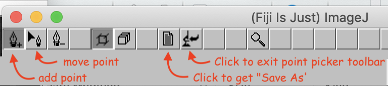